# Assignment 3: Incarceration

Kristi Nguyen

2/22/2021

# Introduction

In this incarceration analysis, I am focusing on the incarceration of juveniles in Washington. I chose this specific target because near my hometown, Lynnwood, there is a large juvenile court nearby in Everett. There is a consistent problem around my hometown where the youth are getting involved in gangs because of the overall high level of crime. I also want to see the differences within Washington to see the varying differences in juveniles. Would cities have more juveniles than more rural places? What proportion of juveniles are in Washington to US juveniles? To answer these questions, I used `county_name`, `male_juvenile_jail_pop`, and `urbanicity` to analyze the data.

# Summary

| year | total_juvy |
| --- | --- |
| 2000 | 0.42 |
| 2001 | 18.33 |
| 2002 | 4.25 |
| 2003 | 12.17 |
| 2004 | 3.08 |
| 2005 | 14.00 |
| 2006 | 10.50 |
| 2007 | 10.00 |
| 2008 | 4.72 |
| 2009 | 30.00 |
| 2010 | 20.00 |
| 2011 | 17.00 |
| 2012 | 20.00 |
| 2013 | 13.00 |

In total, there are 49415 males incarcerated in Washington. Of these males, there are 177.47 juveniles incarcerated. Therefore, the juvenile male proportion to males in jail is 0.004. In the US, there are 14265 juvenile males. Computing the percentage of Washington juveniles to US juveniles, it is 0.012. The county with the highest number of juvenile males is King County, and the year with the highest is 2009. For urbanicity, the one with the highest number of juvenile males is urban. The table shows my area of interest, which is juveniles in Washington. It measures that change in the number of total juveniles over time. Unlike the incarceration of adults, the number of juveniles is pretty low overall, with numbers not even reaching 50 for a single year in Washington.

# Trends over time chart

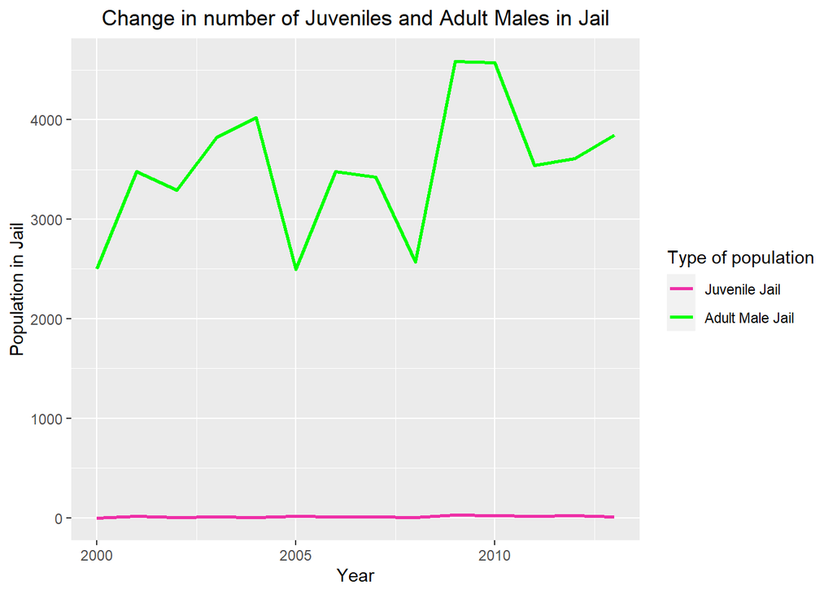

This line chart shows the change in number of juveniles and adult males in jail. I was surprised to see the miniscule number of juvenile there was in comparison to adult males in jail. This tells me that Washington doesn’t have a crisis for juveniles. I was actually expecting more, as it could be influenced by the juvenile problem near my hometown. Around ~2009, there was a big increase in the number of adult males in jail, but the juvenile crime didn’t rise in proportion to that. However, the year with the highest number of juveniles is indeed in 2009. It seems like there was an event in 2009 that increased the level of overall crime, or the criteria for people being imprisoned.

# Variable comparison chart

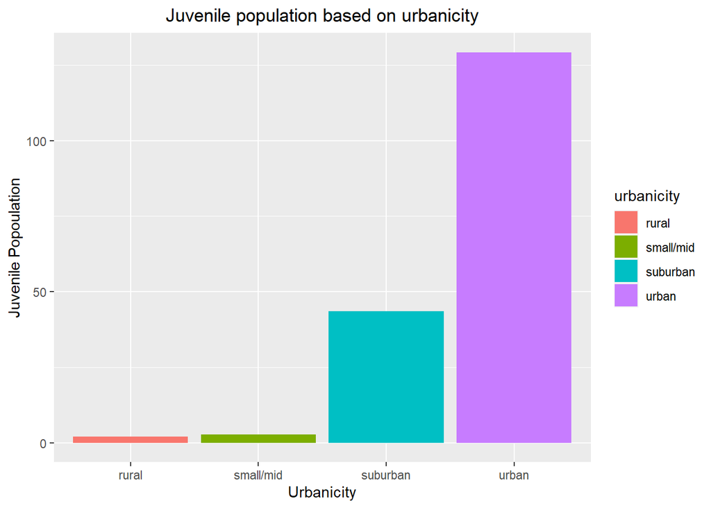

This bar chart visualizes the number of juveniles in different urbanicities: small/mid, rural, suburban, and urban. It can be seen that urban places have a much a higher number of juveniles compared to the other urbanicities. This is expected because urban locations have a higher population of people overall, and more businesses. Naturally, suburban areas have the next highest number because they are not big as cities, but have a considerable amount of people. Rural and small/mid areas have a very small amount of juveniles.

# Map

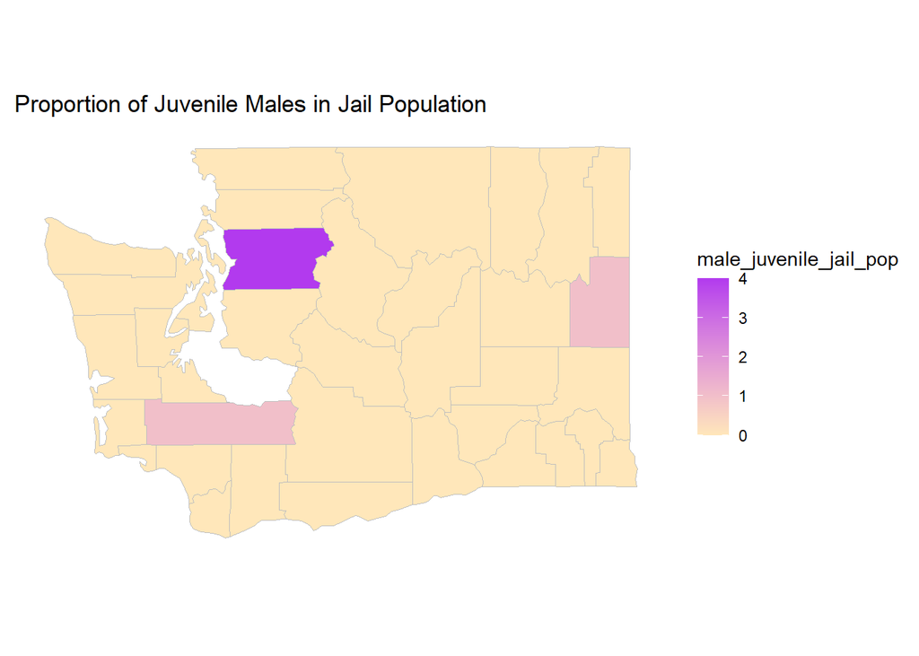

This map shows the number of juveniles in the different counties of Washington in the most recent year in the data, which is 2018. I am surprised to see no juveniles in King County for this year, because they are the county with the highest number of juveniles overall and is the most *urban* county. My hometown, Snohomish county, had the highest as seen in the map. I thought that there would be a higher number of juveniles, but there is quite a small number as visualized in this map.